# 09.Example 3

## Required:

1. What is the drag force on the sphere?
2. What is the rate of heat transfer from the sphere?
3. Generate a plot of the heat transfer from the sphere as a function of the air velocity for the range $1$ to $25 \frac{m}{s}$.

## Solution:

Start first by importing any needed libraries.

```python
import math
import matplotlib.pyplot as plt
import numpy as np
import pint # https://pint.readthedocs.io
```

The unit registry may then be defined. This is shown below.

```python
ureg=pint.UnitRegistry()
Q_=ureg.Quantity
```

The given problem variables may now be defined with units.

```python
T_inf=Q_(25, 'degC')
D=Q_(10, 'mm')
V=Q_(15, 'm/s')
T_s=Q_(75, 'degC')
```

There will be several material properties that need to be interpolated so a Python function will be defined to perform the interpolation function. This is shown below.

```python
def interp(x, x1, x2, y1, y2):
    return ((x-x1)/(x2-x1))*(y2-y1)+y1
```

For this problem, many of the fluid properties must be evaluated at various temperatures. The film temperature $T_f$, far field temperature $T_\infty$, and surface temperature $T_s$ will have properties values. The film temperature is given by  
$T_f=\frac{T_\infty+T_s}{2}$

```python
T_f=(T_inf.to('K')+T_s.to('K'))/2
round(T_f.to('K'), 1)
```

323.1 kelvin

The various properties are found from Table A.4. Different subscripts are used to indicate the temperature at which property is evaluated. This is shown below.

```python
Ta=Q_(250, 'K')
Tb=Q_(300, 'K')
Tc=Q_(350, 'K')
rhob=Q_(1.1614, 'kg/m**3')
rhoc=Q_(0.995, 'kg/m**3')
rho_f=interp(T_f, Tb, Tc, rhob, rhoc)
round(rho_f, 3)
```

1.084 kilogram/meter<sup>3</sup>

```python
mua=Q_(159.6E-7, 'N*s/m')
mub=Q_(185.6E-7, 'N*s/m')
muc=Q_(208.2E-7, 'N*s/m')
mu_inf=interp(T_inf, Ta, Tb, mua, mub)
'{:~.3E}'.format(mu_inf)
```

```
'1.846E-05 N * s / m'
```

```python
mu_s=interp(T_s, Tb, Tc, mub, muc)
'{:~.3E}'.format(mu_s)
```

```
'2.074E-05 N * s / m'
```

```python
nua=Q_(11.44E-6, 'm**2/s')
nub=Q_(15.89E-6, 'm**2/s')
nuc=Q_(20.92E-6, 'm**2/s')
nu_inf=interp(T_inf, Ta, Tb, nua, nub)
'{:~.3E}'.format(nu_inf)
```

```
'1.573E-05 m ** 2 / s'
```

```python
nu_f=interp(T_f, Tb, Tc, nub, nuc)
'{:~.3E}'.format(nu_f)
```

```
'1.822E-05 m ** 2 / s'
```

```python
ka=Q_(22.3E-3, 'W/(m*K)')
kb=Q_(26.3E-3, 'W/(m*K)')
k_inf=interp(T_inf, Ta, Tb, ka, kb)
'{:~.3E}'.format(k_inf)
```

```
'2.615E-02 W / K / m'
```

```python
Pra=Q_(0.72, '')
Prb=Q_(0.707, '')
Pr_inf=interp(T_inf, Ta, Tb, Pra, Prb)
round(Pr_inf, 4)
```

0.7075 dimensionless

Figure 9.2 may be used to obtain the drag coefficient $C_D$. The Reynolds number must first be found. For a sphere in cross flow, the Reynolds number is defined as  
$Re_D=\frac{V D}{\nu}$

```python
Re_D=V*D/nu_f
round(Re_D.to(''), 0)
```

8233.0 dimensionless

The kinematic viscosity $\nu$ evaluated at the film temperature $T_f$ is used here because Figure 9.2 was created using this underlining assumption. Referring to the figure with a Reynolds number approximately equal to $8,233$ shows that the drag coefficient is approximately $C_D=0.4$.

```python
C_D=0.4
```

Using the definition of the drag coefficient, the drag force may be determined. This is shown below.  
$C_D=\frac{F_D}{A_f \frac{\rho V^2}{2}}$  
where $A_f$ is the frontal area of the sphere. The frontal area is given by  
$A_f=\frac{\pi}{4}D^2$

```python
A_f=(math.pi/4)*D**2
round(A_f.to('mm**2'), 2)
```

78.54 millimeter<sup>2</sup>

Using the drag coefficient expression, the drag force is  
$F_D=\frac{C_D A_f \rho V^2}{2}$

```python
F_D=(C_D*A_f*rho_f*V**2)/2
round(F_D.to('mN'), 3)    # answer to part 1
```

3.832 millinewton

The first step in find the heat rate is to determine the average Nusselt number for a sphere in cross flow. This is by first finding the Reynolds number for a sphere. This is shown below.  
$Re_D=\frac{V D}{\nu}$

```python
Re_D=V*D/nu_inf
round(Re_D.to(''), 0)
```

9539.0 dimensionless

The kinematic viscosity $\nu$ is evaluated at the far field temperature $T_\infty$ here because the empirical relation that will be used in the coming steps assumes all the fluid properties are evaluated at the far field temperature unless otherwise noted (as in the case of $\mu_s$). Reviewing the Reynolds number, it may be seen that the Reynolds number falls between the acceptable values of Reynolds numbers for the average Nusselt number empirical relation. The Prandtl number and dynamic viscosity ratio must also be checked. This is shown below.

```python
round(Pr_inf, 2)
```

0.71 dimensionless

```python
round(mu_inf/mu_s, 1)
```

0.9 dimensionless

The Prandtl is within the acceptable range. However, the dynamic viscosity ratio is not exactly within the acceptable range. It is close though. Close enough for this analysis. The average Nusselt number is then given by  
$\bar{Nu}_D=2+\left( 0.4 Re_D^{1/2} + 0.06 Re_D^{2/3} \right) Pr^{0.4} \left( \frac{\mu}{\mu_s} \right)^{1/4}$

```python
Nub_D=2+(0.4*Re_D**(1/2)+0.06*Re_D**(2/3))*Pr_inf**(0.4)*(mu_inf/mu_s)**(1/4)
round(Nub_D, 2)
```

57.87 dimensionless

The average convective coefficient is found by the definition of the Nusselt number. This is shown below.  
$\bar{Nu}_D= \frac{\bar{h} D}{k}$  
Solving the expression for the average convective coefficient shows  
$\bar{h}=\frac{\bar{Nu}_D k}{D}$

```python
hb=Nub_D*k_inf/D
round(hb.to('W/(m**2*K)'), 1)
```

151.3 watt/(kelvin meter<sup>2</sup>)

The heat rate is then given by  
$q=\bar{h}A_s \left( T_s - T_\infty \right)$  
where $A_s$ is givne by  
$A_s=\pi D^2$

```python
A_s=math.pi*D**2
round(A_s.to('mm**2'), 1)
```

314.2 millimeter<sup>2</sup>

```python
q=hb*A_s*(T_s-T_inf)
round(q.to('W'), 3)    # answer to part 2
```

2.377 watt

To create a plot of heat rate $q$ versus velocity $V$ plot steps 17 to 23 must be repeated for the range of velocity values. To aid in this process, a Python function will be created. This is shown below.

```python
def heat_rate(V):
    Re_D=V*D/nu_inf
    Nub_D=2+(0.4*Re_D**(1/2)+0.06*Re_D**(2/3))*Pr_inf**(0.4)*(mu_inf/mu_s)**(1/4)
    hb=Nub_D*k_inf/D
    q=hb*A_s*(T_s-T_inf)
    return q
```

The plotting values for $V$ are created using [Numpy's](https://docs.scipy.org/doc/numpy/index.html) linspace. This is shown below.

```python
Vvals=np.linspace(1, 25, 100)*ureg.m/ureg.s
qvals=heat_rate(Vvals)
```

As of this writing, it appears that there is a bug in the Pint library that causes an error when trying to plot with units. See [here](https://github.com/hgrecco/pint/issues/760) for status of bug. To avoid this, the units will be removed and the unitless values will be plotted. Removing the units is shown below.

```python
Vvals=Vvals.to('m/s').magnitude
qvals=qvals.to('W').magnitude
```

The plotting handle may now be created and plotting elements added to the plot. This is shown below.

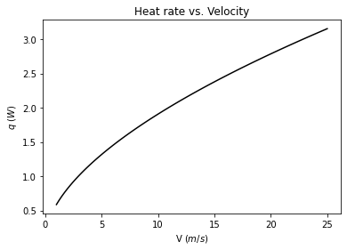

```python
fig, ax=plt.subplots(1, 1)

ax.plot(Vvals, qvals, color='k')

ax.set_xlabel('V $\\left(m/s\\right)$')
ax.set_ylabel('$q\\ \\left( W \\right)$')

ax.set_title('Heat rate vs. Velocity')

plt.show()
```

Download Complete Python Script Here